# Project Milestone

## Skin-Lesion Classification on HAM10000 — Progress Report

**Course:** Introduction to Data Science **Instructor:** Quách Đình Hoàng **Team 07:** Nguyễn Nhật Phát, Bùi Trần Tấn Phát **Milestone deadline:** 12 April 2026

## 1. Member contributions so far

[output not shown]

Both members are on track with the plan submitted in the Proposal.

## 2. Project recap

**Problem.** Multi-class classification of dermatoscopic lesions from the HAM10000 dataset into seven diagnostic categories, with particular emphasis on recall for the melanoma (`mel`) class because of its clinical weight.

**Dataset.** 10,015 dermatoscopic images with metadata (`lesion_id`, `image_id`, `dx`, `dx_type`, `age`, `sex`, `localization`). Class distribution is strongly skewed toward melanocytic nevi (≈ 67%).

**Inputs / outputs.**

**Evaluation.** Primary — **Macro-F1** and **melanoma recall**. Secondary — Accuracy, Weighted-F1, OvR ROC-AUC, confusion matrices.

## 4. Preliminary results

The numbers below are loaded directly from the cached experiment output `../results/results_summary.json` so that this notebook stays consistent with the Report.

```python
import json
from pathlib import Path
import pandas as pd

RESULTS_PATH = Path('..') / 'results' / 'results_summary.json'
with RESULTS_PATH.open('r', encoding='utf-8') as f:
    results = json.load(f)

pd.set_option('display.float_format', lambda x: f'{x:.4f}')
```

### 4.1 Baseline model comparison (all features, default hyperparameters)

```python
model_cmp = pd.DataFrame(results['model_comparison']).sort_values('Macro F1', ascending=False).reset_index(drop=True)
model_cmp
```

|  | Model | Accuracy | Macro F1 | Weighted F1 | ROC-AUC |
| --- | --- | --- | --- | --- | --- |
| 0 | XGBoost | 0.8146 | 0.5782 | 0.8147 | 0.9480 |
| 1 | LightGBM | 0.8166 | 0.5749 | 0.8133 | 0.9418 |
| 2 | Random Forest | 0.7885 | 0.5419 | 0.8016 | 0.9393 |
| 3 | SVM (RBF) | 0.7858 | 0.5310 | 0.7878 | 0.9175 |
| 4 | Logistic Regression | 0.7885 | 0.5201 | 0.8023 | 0.9366 |
| 5 | K-Nearest Neighbors | 0.6961 | 0.3886 | 0.7311 | 0.7440 |

**Reading.** Gradient-boosted trees lead on both Macro-F1 and accuracy: XGBoost reaches **0.815 accuracy / 0.578 macro-F1**, LightGBM **0.817 / 0.575**. Random Forest and Logistic Regression form a second tier; KNN lags far behind, which is expected in a 50-dim feature space dominated by categorical one-hot columns. We will therefore focus the hyperparameter-tuning effort on LightGBM/XGBoost for the final report.

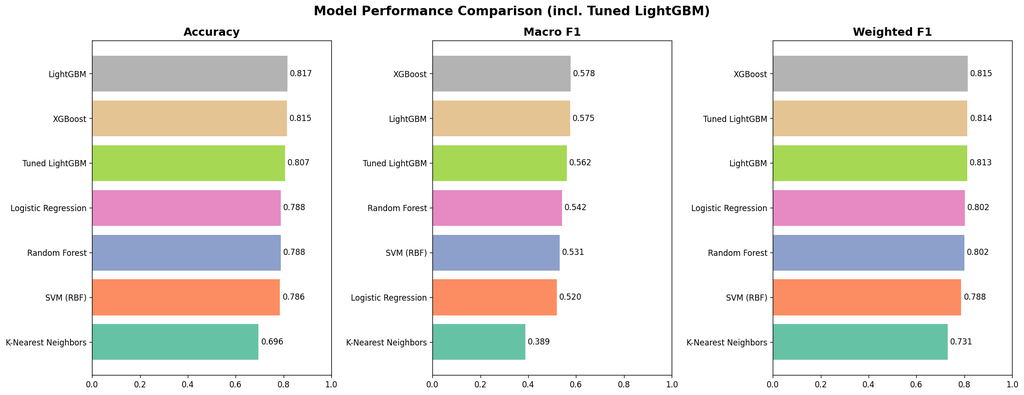

```python
from IPython.display import Image
Image(filename=str(Path('..') / 'results' / 'model_comparison.png'))
```

### 4.2 Feature-set ablation (metadata vs image vs combined)

```python
fs = pd.DataFrame(results['feature_set_comparison']).T
fs.index.name = 'Feature set'
fs.reset_index()
```

|  | Feature set | Accuracy | Macro F1 | Weighted F1 | ROC-AUC | n_features |
| --- | --- | --- | --- | --- | --- | --- |
| 0 | Metadata Only | 0.7135 | 0.4008 | 0.7367 | 0.8751 | 23.0000 |
| 1 | Image Only | 0.7550 | 0.4279 | 0.7581 | 0.9012 | 27.0000 |
| 2 | Combined (Meta+Image) | 0.8106 | 0.5633 | 0.8057 | 0.9455 | 50.0000 |

**Reading.** The combined feature set (metadata + image descriptors, 50 features) is clearly the strongest, beating metadata-only by **+0.097 accuracy** and image-only by **+0.056 accuracy**. ROC-AUC climbs from 0.875 (metadata only) to **0.946** (combined). This directly addresses **RQ3** in the Proposal: the two feature groups are complementary, not redundant.

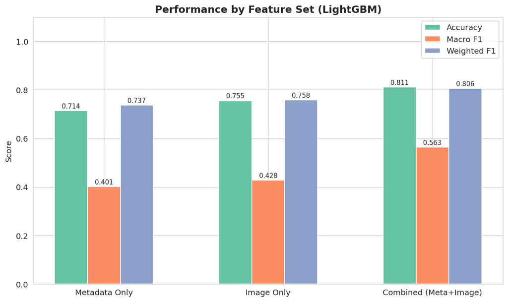

```python
Image(filename=str(Path('..') / 'results' / 'feature_set_comparison.png'))
```

```python
bm = results['best_model']
pd.Series({
    'Model':       bm['name'],
    'Accuracy':    bm['accuracy'],
    'Macro F1':    bm['macro_f1'],
    'Weighted F1': bm['weighted_f1'],
    'ROC-AUC':     bm['roc_auc'],
}).to_frame('Value')
```

|  | Value |
| --- | --- |
| Model | Tuned LightGBM |
| Accuracy | 0.8066 |
| Macro F1 | 0.5621 |
| Weighted F1 | 0.8137 |
| ROC-AUC | 0.9456 |

```python
pd.Series(bm['best_params']).to_frame('Best LightGBM hyperparameter')
```

|  | Best LightGBM hyperparameter |
| --- | --- |
| subsample | 0.7 |
| reg_lambda | 1.0 |
| reg_alpha | 0 |
| num_leaves | 50 |
| n_estimators | 300 |
| min_child_samples | 30 |
| max_depth | 5 |
| learning_rate | 0.03 |
| colsample_bytree | 0.7 |

### 4.4 Melanoma-specific performance (baseline)

```python
mm = results['melanoma_metrics']
pd.Series({'Recall': mm['recall'], 'Precision': mm['precision'], 'F1': mm['f1']}).to_frame('Melanoma (baseline)')
```

|  | Melanoma (baseline) |
| --- | --- |
| Recall | 0.5447 |
| Precision | 0.4653 |
| F1 | 0.5019 |

**Reading.** At the default argmax decision rule, melanoma recall is only **0.54** — meaning the model misses almost half of actual melanoma cases. This is the single biggest clinical weakness of the baseline and is the focus of the remaining work.

### 4.5 Supporting figures

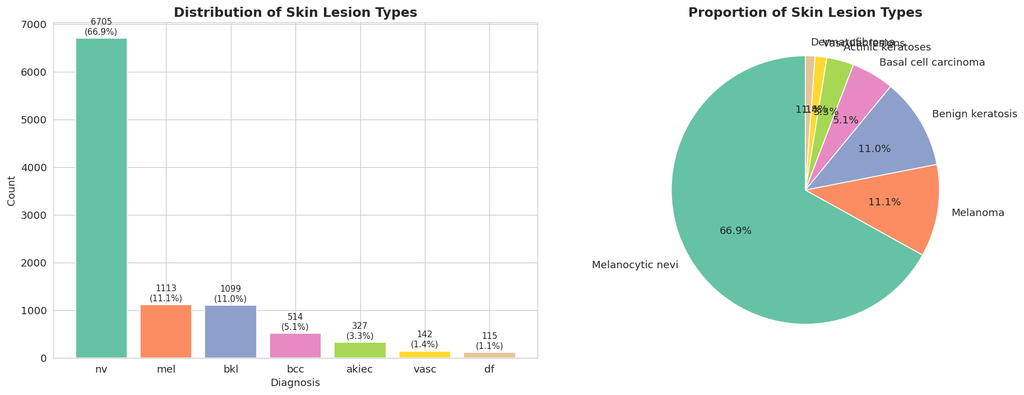

```python
Image(filename=str(Path('..') / 'results' / 'class_distribution.png'))
```

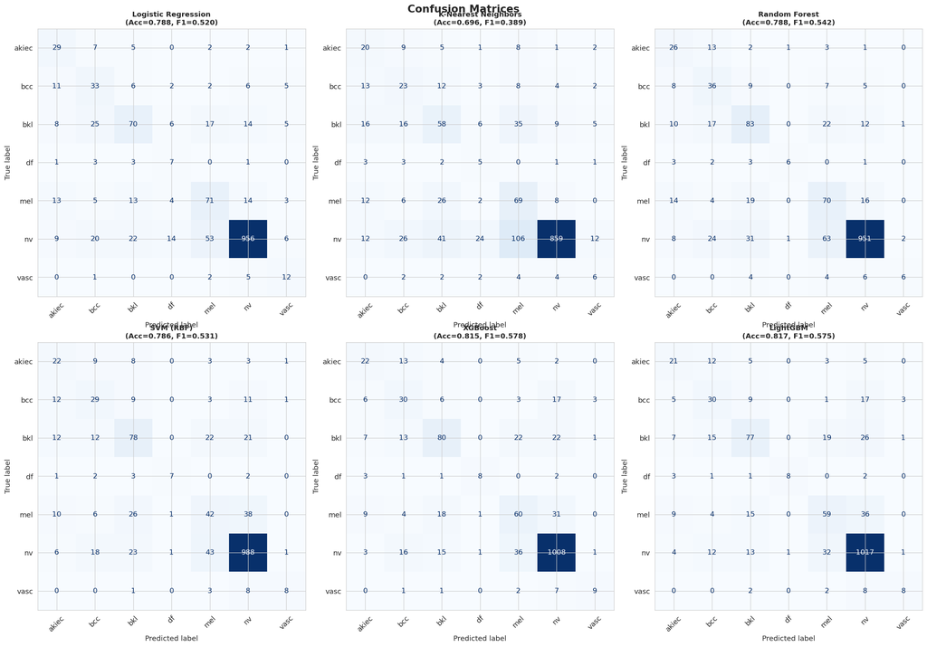

```python
Image(filename=str(Path('..') / 'results' / 'confusion_matrices.png'))
```

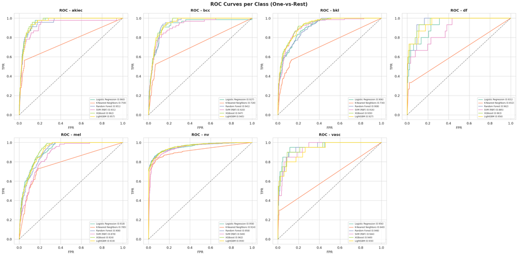

```python
Image(filename=str(Path('..') / 'results' / 'roc_curves.png'))
```

## 5. Discussion of preliminary results

1. **Statistical tests (RQ1) are conclusive.** Both `sex` and `localization` are significantly associated with `dx`, and age distributions differ between diagnostic groups. This confirms that metadata carries useful predictive signal and is not just a nuisance covariate.
2. **Combined features dominate (RQ3).** The feature-set ablation shows a clear ordering `Metadata < Image < Combined` on every metric we care about. This is an important finding for the final report because it motivates the whole pipeline design.
3. **The overall classifier is competitive but melanoma recall is not.** A Macro-F1 of ~0.58 and ROC-AUC ≈ 0.95 are solid for tabular ML on HAM10000, but a 0.54 recall on `mel` is clinically unacceptable. Most errors are `mel → nv` confusions, consistent with the dermatological literature.
4. **Class imbalance is the root cause.** Even with `class_weight='balanced'` and SMOTE, the dominant `nv` class biases the default argmax decision. This tells us that **threshold tuning** and/or a **dedicated binary mel-vs-rest classifier** are the right next steps, rather than chasing yet another model family.

## 6. Plan for the remaining weeks

| Week | Action | Expected deliverable |
| --- | --- | --- |
| 12 – 18 Apr | Randomised hyperparameter search on LightGBM with 5-fold CV; refresh feature-importance analysis. | Updated `results_summary.json`, feature-importance plots. |
| 12 – 18 Apr | Train a **binary mel-vs-rest LightGBM** with aggressive SMOTE and `scale_pos_weight`; sweep decision threshold. | `mel_improvement_summary.json`, ROC/PR curves for mel. |
| 19 – 22 Apr | **Two-tier pipeline**: binary gate + 7-class model; threshold sweep on the 7-class mel probability. | Side-by-side table of (baseline, threshold-tuned, binary, two-tier). |
| 19 – 22 Apr | Presentation rehearsal, slide polish, 10-minute timing. | `Presentation/Presentation.pptx`. |
| 23 – 26 Apr | Final Report narrative, reproducibility appendix, HTML/PDF export, peer assessment. | `Report/Report.ipynb` + `Report.html`. |

**Risks & mitigations.**

- *Image-feature extraction is slow (~10 min).* → Cache the output in `results/image_features.csv` so modelling experiments become cheap and reproducible.
- *Hyperparameter search may over-fit on the validation folds.* → Report test-set metrics only once after model selection; never use the test split for tuning.
- *Two-tier pipeline could hurt macro-F1.* → Always report *both* the melanoma recall and the overall macro-F1 so the trade-off is explicit.